# Nesting data frames

John Little

2022-09-02

One way to leverage what we’ve learned in previous lessons (functions, purrr/map, regex, ggplot2, dplyr) is to use the `nest` function. Nesting will create group-specific tibbles upon which which you can map more functional analysis.

```r
library(tidyverse)
```

## `group_by` and nest

While `group_by` is not specifically required (see next code-chunk) to `nest`, I find that it helps me when I’m trying to leverage ggplot functions as you’ll see below.

```r
starwars |>
  group_by(gender) |>
  nest()
```

| gender | data |
| --- | --- |
| masculine |  |
| feminine |  |
| NA |  |

### `nest` without group_by

```r
starwars |>
  nest(-gender)
```

| gender | data |
| --- | --- |
| masculine |  |
| feminine |  |
| NA |  |

## map a custom function over a nested group

Building on lesson three where we created custom functions, we can map those functions onto our embedded tibbles

```r
make_me_a_plot <- function(df) {
  df %>%
    ggplot(aes(height, mass)) +
    geom_point()
}

starwars |>
  nest(data = -gender) |>
  mutate(my_plot = map(data, make_me_a_plot)) |>
  pull(my_plot)
```

[output not shown]

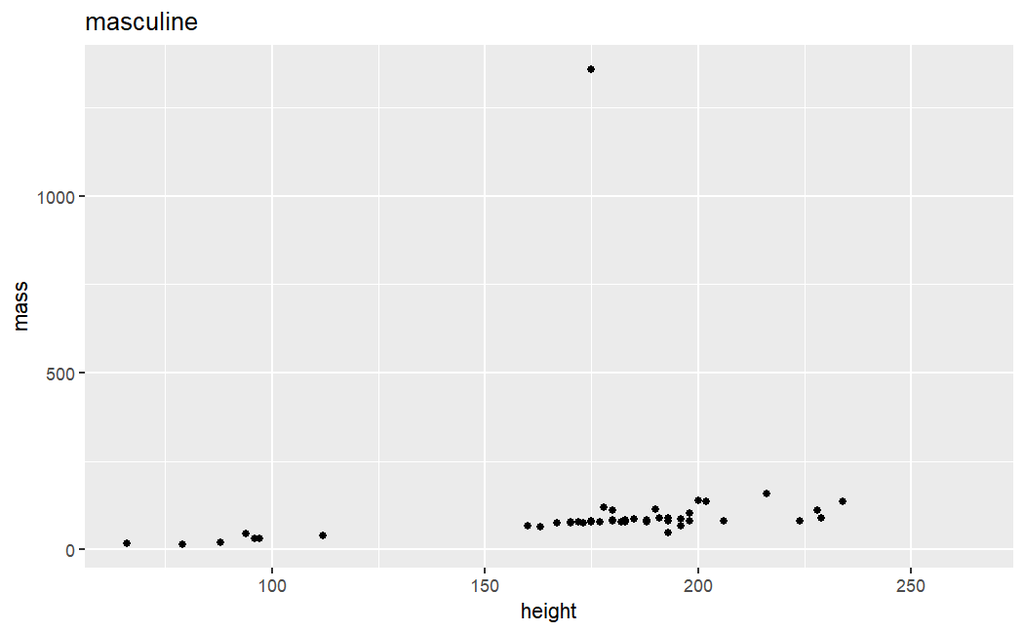

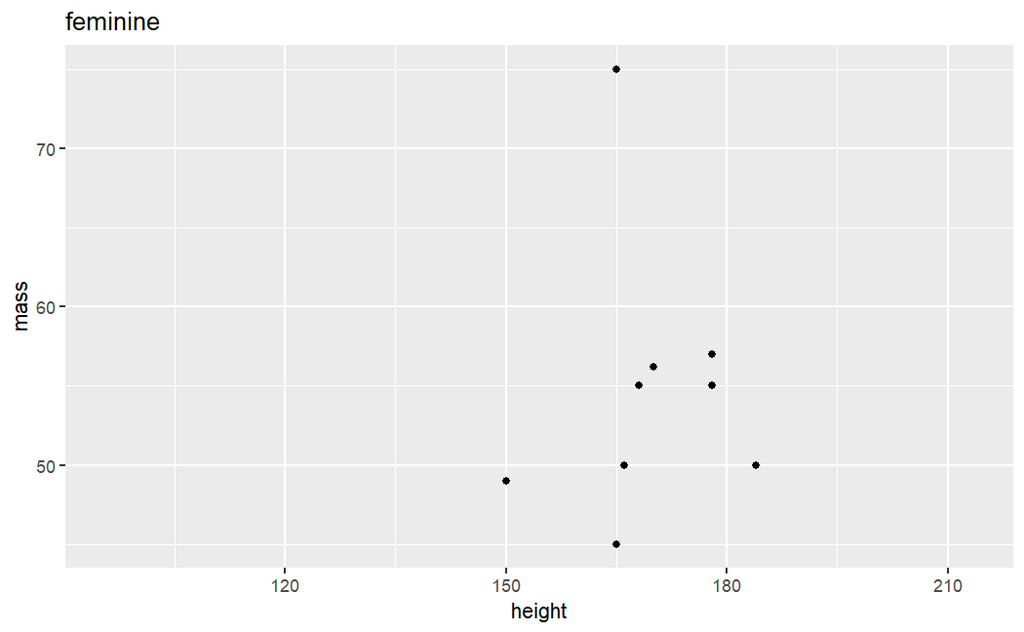

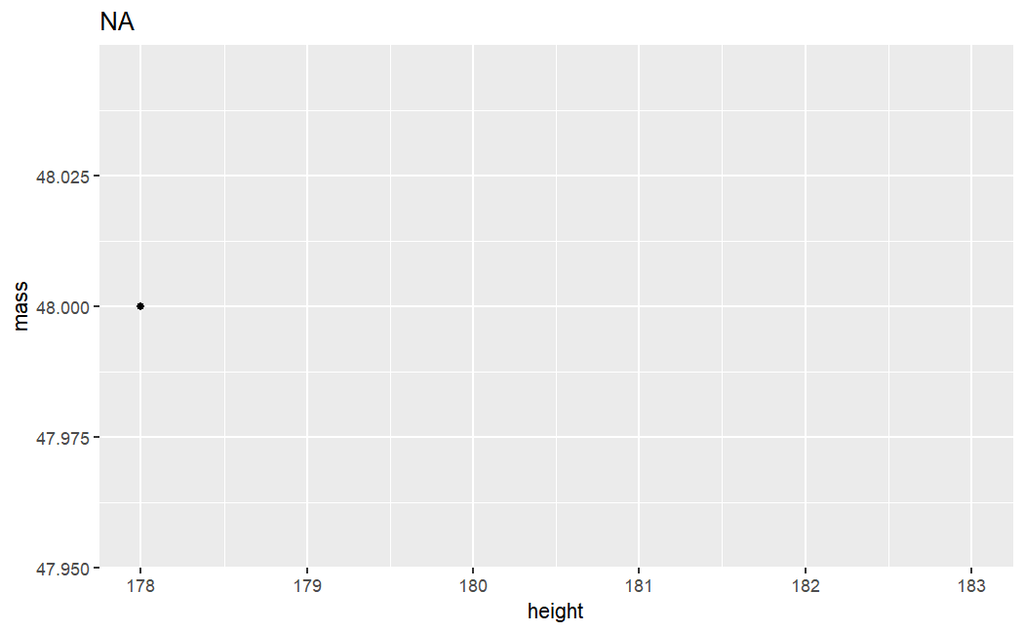

```r
starwars |>
  group_by(gender) |>
  nest(my_df = -gender) |>
  mutate(my_plot = map(my_df, make_me_a_plot)) |>
  mutate(my_plot_with_title = map(my_plot, ~ .x + ggtitle(gender))) |>
  pull(my_plot_with_title)
```

### Models and mapping other functions

```r
starwars |>
  group_by(sex) |>
  nest(-sex) |>
  mutate(my_plot = map(data, make_me_a_plot)) |>
  mutate(my_plott = map(my_plot, ~ .x + labs(title = sex))) |>
  mutate(my_model = map(data, ~ lm(mass ~ height, data = .x))) |>
  mutate(my_tidy_model = map(my_model, broom::tidy)) #|>
```

| sex | data | my_plot | my_plott | my_model | my_tidy_model |
| --- | --- | --- | --- | --- | --- |
| male |  |  |  |  |  |
| none |  |  |  |  |  |
| female |  |  |  |  |  |
| hermaphroditic |  |  |  |  |  |
| NA |  |  |  |  |  |

```r
  # unnest(my_tidy_model) |>
  # filter(term != "(Intercept)") |>
  # filter(p.value < 0.05) |>
  # mutate(my_reg_plot = map(data, ~ .x |>
  #                            ggplot(aes(height, mass)) +
  #                            geom_smooth(method = lm, se = FALSE) +
  #                            geom_point())) |>
  # pull(my_reg_plot)
```

## `map2()` - Iterating over more than a single parallel vector

In the section about mapping custom functions, I use the `group_by()`, `nest()` and `map()` functions to generate plots with titles. the `.x` pronoun refers to the object I want to iterate over. That code works fine even if it’s a little verbose. It also demonstrates the value of additional {purrr} functions. `map2()` iterates over two vectors in parallel. Similarly, `pmap()` iterates over a list of multiple vectors.

In the case of `map2()` the two vectors of a parent data-frame can be referred to by the pronouns `.x` and `.y`. So, one vector is the title of the plot (`.y`), the other vector (`.x`) is the list-column tibble that contains the x-axis and y-axis vectors generating a scatter plot for each nested tibble.

Essentially, coding with `map2()` creates the scatter plots with a bit less code

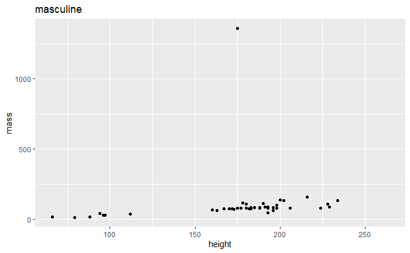

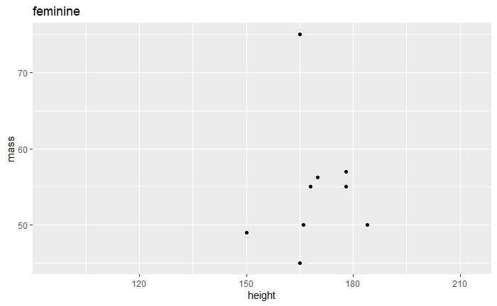

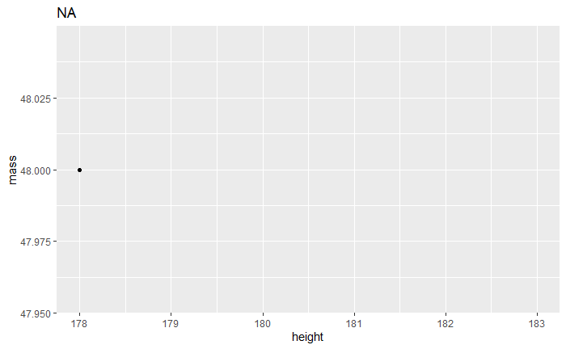

```r
starwars |>
  nest(my_df = -gender) |>
  mutate(my_plot = map2(my_df, gender, ~ .x |>
                          ggplot(aes(height, mass)) +
                          geom_point() +
                          ggtitle(.y))) |>
  pull(my_plot)
```

Of course, the anonymous function can be written as a named function, making the code even more readable

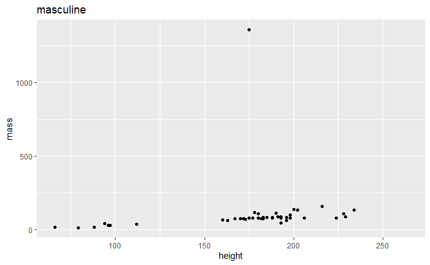

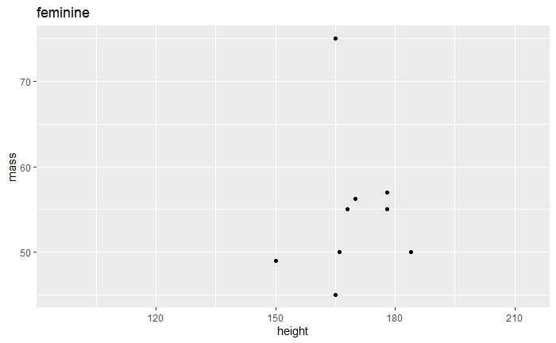

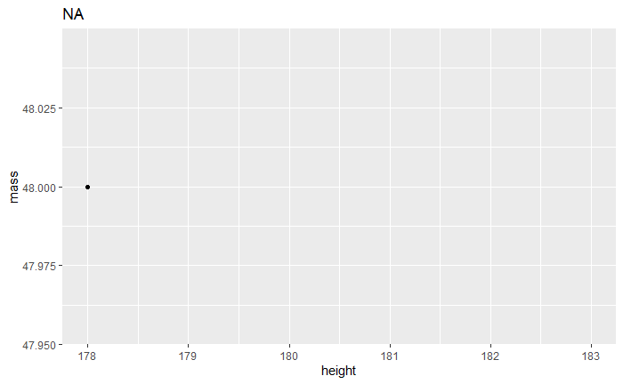

```r
starwars |>
  nest(my_df = -gender) |>
  mutate(my_plot = map2(my_df, gender, splot_title)) |>
  pull(my_plot)
```

[output not shown]